# Cause or Signature? The “Village” and Parental Depression in FFCWS

Latent trajectory clustering and a four-rung causal ladder testing whether social support moves parental depression

SSPP Research

2026-06-26

> **Scope & framing.** This notebook covers the FFCWS analysis end to end: data construction, latent trajectory clustering, and within-person modeling of social support (“the Village”) and parental depression.

> **Key framing.** This is a *social-support → parental-depression* study covering **mothers and fathers**; cohort = births 1998–2000. The outcome is binary CIDI-SF major-depression caseness — the only depression measure repeated at all four waves for both parents.

# 1 Configuration

```r
WAVES <- c(2, 3, 4, 5)                                  # 2=Year1, 3=Year3, 4=Year5, 5=Year9
WAVE_LABEL <- c("2"="Year 1","3"="Year 3","4"="Year 5","5"="Year 9")
GAD_WAVES <- c(2, 3)                                    # GAD caseness fielded Years 1 & 3 only

# Feature engineering lives ONCE in the canonical pipeline (scripts/pipeline/, defined in
# sources.py and validated by `pytest scripts/pipeline/tests`). This document is a pure
# CONSUMER of the resulting marts — no inline re-derivation from the raw .dta. The 6-item
# perceived-support battery, the enacted (received-from-kin) and grandparent (co-residence)
# facets, and the graded family-history construct all originate there.
MARTS <- list(caseness = file.path(PROC, "ffcws_parental_mh_long.csv"),  # CIDI caseness panel
              vuln     = file.path(PROC, "preexisting_vuln.csv"),        # family-history + CES-D
              village  = file.path(PROC, "village_wave.csv"),            # wave-level village facets
              panel    = file.path(PROC, "village_panel_tv.csv"))        # lagged-transition panel
```

# 2 Preprocessing — load the canonical feature marts

This document loads the tested marts produced by `scripts/pipeline/` (run `python3 -m scripts.pipeline.build`): the CIDI caseness panel, the family-history / CES-D vulnerability table, the wave-level Village facets, and the lagged-transition panel. Every definition — the **6-item** perceived-support battery, the **enacted** (received-from-kin) and **grandparent** (co-residence) facets, and the **graded** multi-symptom family history — is shared with the predictive pipeline.

```r
# (a) CIDI caseness panel + covariates
long <- read.csv(MARTS$caseness) |>
  filter(wave %in% WAVES) |>
  transmute(idnum = as.integer(idnum), parent, wave,
            md_case_lib, md_case_con, gad_case, poverty_cat, par_edu, par_age) |>
  filter(!(is.na(md_case_lib) & is.na(md_case_con)))
write.csv(long, file.path(PROC, "rmd_caseness_long.csv"), row.names = FALSE)

# (b) family-history vulnerability + father baseline CES-D (graded columns also present)
vuln <- read.csv(MARTS$vuln)

# (c) wave-level Village facets (perceived / enacted / grandparent / realized)
support_long <- read.csv(MARTS$village) |> mutate(idnum = as.integer(idnum))

cat(sprintf("marts loaded | caseness rows %d | fh prevalence mother %.3f / father %.3f | father CES-D mean %.1f\n",
            nrow(long), mean(vuln$fh_mother, na.rm=TRUE), mean(vuln$fh_father, na.rm=TRUE),
            mean(vuln$cesd_father_baseline, na.rm=TRUE)))
```

```
## marts loaded | caseness rows 28674 | fh prevalence mother 0.335 / father 0.296 | father CES-D mean 13.2
```

**What the marts encode.** `fh` substitutes for the pre-partum baseline FFCWS never collected — **family history of depression** (bio-parent ever depressed 2wk+), asked at Year 3 and filled from Year 5 for coverage (zero Y3/Y5 overlap, so a union not a re-measure). The mart also carries graded `fh_*_burden/severity/suicide`; the models below use the binary `fh_mother`/`fh_father`. `v_instrumental` is the 6-item battery (loan $200/$1000, place to live, emergency childcare, co-sign $1000/$5000).

> **Note on `fh` measurement (recall bias).** A single retrospective family-history report is colored by the respondent’s mood at interview (mood-congruent recall — depressed respondents over-report). FFCWS asked the Year-5 items *only of those missed at Year 3* (zero overlap), so a test–retest is impossible and the union adds coverage only. The recall-bias caveat stands as a limitation; it cannot be differenced out.

> **Deliberate exclusion:** the childcare/partner-care facet is *not* pooled — its response scale differs across waves and it carries an informative “no father to count on” code. The **enacted** facet (`v_enacted`, borrowed-from-kin) is kept as a SEPARATE feature (expected reverse-signed via support mobilization), never folded into the perceived-support index.

## 2.1 Discovery / holdout split (family level)

```r
fams <- sort(unique(long$idnum))
disc_ids <- sample(fams, size = floor(0.6 * length(fams)))
long$split <- ifelse(long$idnum %in% disc_ids, "discovery", "holdout")
```

# 3 Exploratory summary

```r
long |> filter(!is.na(md_case_lib)) |>
  group_by(parent, wave) |>
  summarise(n = n(), dep_rate = mean(md_case_lib), .groups = "drop") |>
  mutate(child_age = WAVE_LABEL[as.character(wave)]) |>
  knitr::kable(digits = 3, caption = "CIDI major-depression caseness prevalence by wave and parent")
```

CIDI major-depression caseness prevalence by wave and parent

| parent | wave | n | dep_rate | child_age |
| --- | --- | --- | --- | --- |
| father | 2 | 3376 | 0.104 | Year 1 |
| father | 3 | 3291 | 0.143 | Year 3 |
| father | 4 | 3146 | 0.116 | Year 5 |
| father | 5 | 2647 | 0.144 | Year 9 |
| mother | 2 | 4362 | 0.155 | Year 1 |
| mother | 3 | 4221 | 0.206 | Year 3 |
| mother | 4 | 4129 | 0.170 | Year 5 |
| mother | 5 | 3502 | 0.175 | Year 9 |

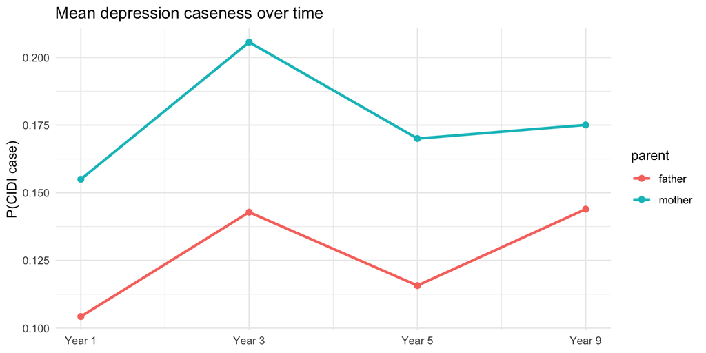

```r
long |> filter(!is.na(md_case_lib)) |>
  group_by(parent, wave) |> summarise(dep = mean(md_case_lib), .groups="drop") |>
  ggplot(aes(wave, dep, color = parent)) + geom_line(linewidth = 1) + geom_point(size = 2) +
  scale_x_continuous(breaks = WAVES, labels = WAVE_LABEL[as.character(WAVES)]) +
  labs(title = "Mean depression caseness over time", y = "P(CIDI case)", x = NULL) + theme_minimal()
```

# 4 Stage 1 — Trajectory clustering (GBTM, flexmix)

```r
fit_gbtm <- function(parent){
  d <- long |> filter(parent == !!parent, split == "discovery", !is.na(md_case_lib))
  st <- stepFlexmix(cbind(md_case_lib, 1 - md_case_lib) ~ poly(wave, 2) | idnum,
                    data = d, k = 1:4, model = FLXMRglm(family = "binomial"),
                    nrep = 4, verbose = FALSE)
  best <- getModel(st, "BIC")
  # per-unit modal class
  units <- d |> mutate(cl = clusters(best)) |> group_by(idnum) |>
    summarise(cl = as.integer(names(which.max(table(cl)))), .groups = "drop")
  # label persistent = higher mean caseness
  mu <- d |> mutate(cl = clusters(best)) |> group_by(cl) |> summarise(m = mean(md_case_lib), .groups="drop")
  persist <- mu$cl[which.max(mu$m)]
  units$class <- ifelse(units$cl == persist, "persistent", "rarely")
  list(step = st, best = best, units = units, data = d, mu = mu)
}
G <- lapply(c("mother","father"), fit_gbtm); names(G) <- c("mother","father")

for (p in c("mother","father")) {
  st <- G[[p]]$step
  cat(sprintf("\n[%s] BIC by k: %s | chosen k = %d\n", p,
              paste(sprintf("%.0f", BIC(st)), collapse = " "), G[[p]]$best@k))
  print(table(G[[p]]$units$class))
}
```

```
##
## [mother] BIC by k: 9110 8328 8339 8373 | chosen k = 2
##
## persistent     rarely
##        488       2340
##
## [father] BIC by k: 5839 5498 5522 5557 | chosen k = 2
##
## persistent     rarely
##        318       2127
```

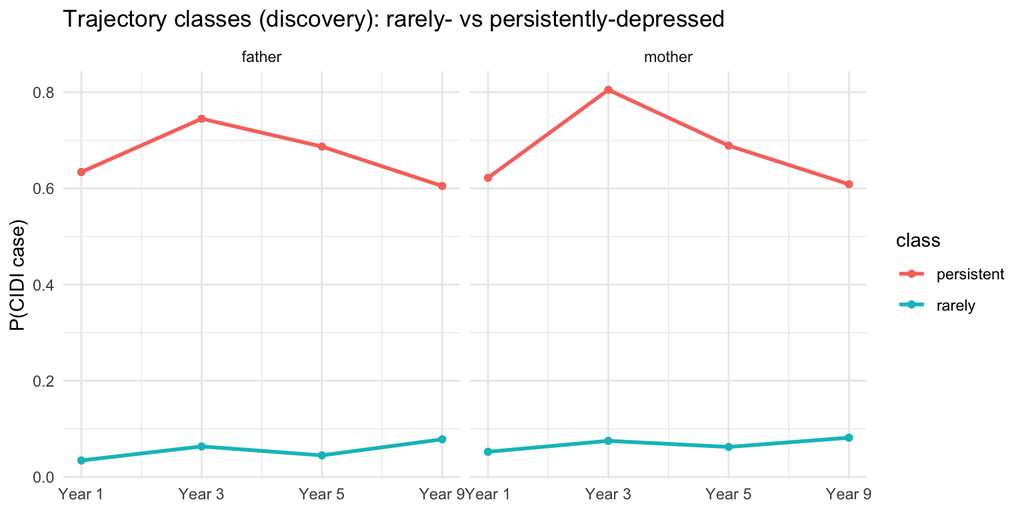

```r
prof <- bind_rows(lapply(c("mother","father"), function(p){
  G[[p]]$data |> left_join(G[[p]]$units[,c("idnum","class")], by = "idnum") |>
    group_by(parent, class, wave) |> summarise(dep = mean(md_case_lib), .groups = "drop")
}))
ggplot(prof, aes(wave, dep, color = class)) + geom_line(linewidth = 1) + geom_point() +
  facet_wrap(~parent) +
  scale_x_continuous(breaks = WAVES, labels = WAVE_LABEL[as.character(WAVES)]) +
  labs(title = "Trajectory classes (discovery): rarely- vs persistently-depressed",
       y = "P(CIDI case)", x = NULL) + theme_minimal()
```

# 5 Stage 2 — Predictors of the persistent class

Does pre-existing **vulnerability** (`fh`) or **SES** drive persistent-class membership? We use flexmix’s **concomitant** (covariate → class) model, which estimates the membership multinomial jointly with the trajectory model. Predictors are standardized (OR per SD).

```r
stage2 <- function(parent){
  fhcol <- paste0("fh_", parent)
  d <- long |> filter(parent == !!parent, !is.na(md_case_lib)) |>
    left_join(vuln[, c("idnum", fhcol)], by = "idnum") |> rename(fh = !!fhcol) |>
    filter(!is.na(fh), !is.na(poverty_cat), !is.na(par_edu))
  d$fhz <- z(d$fh); d$povz <- z(d$poverty_cat); d$eduz <- z(d$par_edu)
  m <- flexmix(cbind(md_case_lib, 1 - md_case_lib) ~ poly(wave, 2) | idnum, data = d, k = 2,
               model = FLXMRglm(family = "binomial"),
               concomitant = FLXPmultinom(~ fhz + povz + eduz))
  mu <- sapply(1:2, function(k) weighted.mean(d$md_case_lib, posterior(m)[, k]))
  persist <- which.max(mu)
  cf <- m@concomitant@coef
  nonref <- which(colSums(abs(cf)) > 1e-8)[1]
  s <- if (persist == nonref) 1 else -1
  data.frame(parent = parent, predictor = c("family history (fh)","poverty ratio","education"),
             OR_per_SD = exp(s * cf[c("fhz","povz","eduz"), nonref]))
}
s2 <- bind_rows(lapply(c("mother","father"), stage2))
knitr::kable(s2, digits = 3, row.names = FALSE,
             caption = "Stage-2: OR per SD for persistent-class membership (concomitant model)")
```

Stage-2: OR per SD for persistent-class membership (concomitant model)

| parent | predictor | OR_per_SD |
| --- | --- | --- |
| mother | family history (fh) | 2.567 |
| mother | poverty ratio | 0.767 |
| mother | education | 0.855 |
| father | family history (fh) | 2.411 |
| father | poverty ratio | 0.873 |
| father | education | 0.706 |

**Family history strongly dominates.** Its OR/SD dwarfs both SES terms, which are weak and run in the expected direction (lower SES → modestly higher persistence): persistent parental depression is mostly *continuation of pre-existing vulnerability*, and the SES→depression link is largely confounded by that vulnerability.

> *Robustness note.* A bias-adjusted three-step (BCH) on a held-out subsample (run separately) gives the same qualitative conclusion with a more conservative `fh` OR (~1.3/SD). The one-step concomitant is more efficient but can overstate class separation; both agree that vulnerability ≫ SES.

# 6 Build the within-person Village panel

Exposure is taken at the **prior** wave (support → *subsequent* depression), so each row is a transition Yt₋₁ → Yt with the lagged Village facets.

```r
# fh in long form + a wave-level `base` (used by the reverse-lag and synthesis sections)
fh_long <- vuln |> select(idnum, fh_mother, fh_father) |>
  pivot_longer(-idnum, names_to = "parent", values_to = "fh") |>
  mutate(parent = sub("fh_", "", parent))

base <- long |> select(idnum, parent, wave, md_case_lib, md_case_con, poverty_cat, par_edu) |>
  left_join(support_long, by = c("idnum","parent","wave")) |>
  left_join(fh_long, by = c("idnum","parent"))

# the lagged-transition panel (prior-wave exposure -> next-wave caseness) is consumed
# DIRECTLY from the canonical mart — Y1->Y3, Y3->Y5, Y5->Y9 construction, with the
# perceived/enacted/grandparent facets alongside v_instrumental.
panel <- read.csv(MARTS$panel) |> mutate(idnum = as.integer(idnum)) |>
  filter(!is.na(dep_t), !is.na(dep_prev))
write.csv(panel, file.path(PROC, "rmd_village_panel_tv.csv"), row.names = FALSE)
cat(sprintf("Panel: %d transition-rows, %d families\n", nrow(panel), length(unique(panel$idnum))))
```

```
## Panel: 18928 transition-rows, 4456 families
```

```r
# Does support actually vary WITHIN person? (the identification base)
for (p in c("mother","father")) {
  d <- panel |> filter(parent == p, !is.na(v_instrumental)) |>
    group_by(idnum) |> mutate(pm = mean(v_instrumental)) |> ungroup()
  multi <- d |> group_by(idnum) |> filter(n() >= 2)
  cat(sprintf("%s: between-person SD %.3f | within-person SD %.3f\n",
              p, sd(d$pm), sd(d$v_instrumental - d$pm)))
}
```

```
## mother: between-person SD 0.251 | within-person SD 0.139
## father: between-person SD 0.237 | within-person SD 0.130
```

Within-person SD is a substantial fraction of between-person SD — support genuinely changes within individuals, so within-person effects are identifiable.

# 7 The causal ladder — reader’s guide

| Rung | Test | Removes / answers | Leaves open → |
| --- | --- | --- | --- |
| **1** | Within-person (Mundlak + FE logit) | *all time-invariant* confounding — each parent is their own control | *time-varying* confounding |
| **2** | E-value sensitivity | how strong an unmeasured confounder must be to erase the surviving effect | *(quantifies, does not remove)* |
| **3** | Cross-lagged reverse test | reverse causation (depression → lower future support) | — |
| **4** | Terminal new-onset subgroup | tests the thesis directly in its cleanest pro-thesis slice | — |

# 8 Rung 1 — Within-person modeling (removes stable confounding)

> **Rung 1 of 4 · the core test.** *Removes:* every time-invariant confounder (genes, upbringing, stable disposition) by using each parent as their own control. *Leaves open:* time-varying confounding — a life shock that moves support and mood together — addressed at Rung 2.

We decompose lagged support (Mundlak / within-between): **person-mean** = the between-person term (confounded by stable disposition); **wave-deviation** = the within-person “mitigation” term. Two estimators: a Mundlak-decomposed **GEE logit** (cluster-robust) and a **conditional fixed-effects logit** (pure within).

```r
  # 95% CI from a GEE coefficient row: exp(Estimate ± 1.96*Std.err)
  ci <- function(cf, term) exp(cf[term, "Estimate"] + c(-1.96, 1.96) * cf[term, "Std.err"])

  # one village facet at a time -> Mundlak between/within decomposition (the facet ablation)
  fit_within <- function(parent, facet = "v_perceived"){
    d <- panel |> filter(parent == !!parent) |>
      select(idnum, dep_t, dep_prev, wave_out, x = all_of(facet), fh, poverty_cat, par_edu) |> na.omit()
    d$x <- z(d$x); d$poverty_cat <- z(d$poverty_cat); d$par_edu <- z(d$par_edu)
    d <- d |> group_by(idnum) |> mutate(x_ib = mean(x), x_iw = x - x_ib) |>
      ungroup() |> arrange(idnum)
    # FE-informative sample — distinguishes a PRECISE within-null from an underpowered one.
    # The clogit likelihood uses only outcome-discordant strata; the x_iw coefficient is only
    # identified for parents whose exposure ALSO moves -> report both counts alongside the OR.
    inf <- d |> group_by(idnum) |>
      summarise(out_disc = dplyr::n_distinct(dep_t) > 1,
                exp_var  = (max(x_iw) - min(x_iw)) > 1e-9, .groups = "drop")
    g <- geeglm(dep_t ~ dep_prev + factor(wave_out) + x_ib + x_iw + fh + poverty_cat + par_edu + x_iw:fh,
                id = idnum, data = d, family = binomial, corstr = "exchangeable")
    cg <- summary(g)$coefficients
    # binary facets (grandparent/religion/enacted) may have too few within-person switchers
    # for the conditional FE logit -> guard it and report NA rather than aborting the table.
    cc <- tryCatch(summary(clogit(dep_t ~ dep_prev + x_iw + I(x_iw*fh) + factor(wave_out) +
                                  strata(idnum), data = d))$coefficients,
                   error = function(e) NULL)
    bt <- ci(cg, "x_ib"); wn <- ci(cg, "x_iw")
    data.frame(
      facet            = facet, parent = parent,
      n_persons        = dplyr::n_distinct(d$idnum),
      n_out_disc       = sum(inf$out_disc),                  # outcome-discordant (clogit-informative)
      n_fe_units       = sum(inf$out_disc & inf$exp_var),    # ALSO exposure-moving (identify x_iw)
      between_OR       = exp(cg["x_ib","Estimate"]), between_lo = bt[1], between_hi = bt[2],
      between_p        = cg["x_ib","Pr(>|W|)"],
      within_GEE_OR    = exp(cg["x_iw","Estimate"]), within_lo  = wn[1], within_hi  = wn[2],
      within_GEE_p     = cg["x_iw","Pr(>|W|)"],
      within_clogit_OR = if (!is.null(cc)) exp(cc["x_iw","coef"]) else NA_real_,
      within_clogit_p  = if (!is.null(cc)) cc["x_iw","Pr(>|z|)"] else NA_real_,
      buffering_OR     = exp(cg["x_iw:fh","Estimate"]), buffering_p = cg["x_iw:fh","Pr(>|W|)"]
    )
  }
  FACETS <- c("v_perceived", "v_enacted", "v_grandparent", "v_religion")
  W <- bind_rows(lapply(FACETS, function(f)
         bind_rows(lapply(c("mother","father"), fit_within, facet = f))))
  knitr::kable(W, digits = 3, row.names = FALSE,
               caption = "Between- vs within-person effect of each village facet on next-wave depression")
```

Between- vs within-person effect of each village facet on next-wave depression

| facet | parent | n_persons | n_out_disc | n_fe_units | between_OR | between_lo | between_hi | between_p | within_GEE_OR | within_lo | within_hi | within_GEE_p | within_clogit_OR | within_clogit_p | buffering_OR | buffering_p |
| --- | --- | --- | --- | --- | --- | --- | --- | --- | --- | --- | --- | --- | --- | --- | --- | --- |
| v_perceived | mother | 4098 | 954 | 735 | 0.762 | 0.714 | 0.814 | 0.000 | 1.080 | 0.928 | 1.257 | 0.322 | 0.966 | 0.696 | 1.028 | 0.787 |
| v_perceived | father | 3119 | 511 | 356 | 0.764 | 0.707 | 0.826 | 0.000 | 0.988 | 0.821 | 1.188 | 0.894 | 0.940 | 0.602 | 1.055 | 0.704 |
| v_enacted | mother | 4126 | 1001 | 472 | 1.409 | 1.314 | 1.510 | 0.000 | 0.908 | 0.807 | 1.021 | 0.107 | 1.027 | 0.689 | 1.001 | 0.994 |
| v_enacted | father | 2813 | 370 | 125 | 1.246 | 1.132 | 1.371 | 0.000 | 0.737 | 0.600 | 0.905 | 0.004 | 0.855 | 0.243 | 1.385 | 0.026 |
| v_grandparent | mother | 4118 | 989 | 272 | 1.050 | 0.978 | 1.128 | 0.178 | 0.987 | 0.868 | 1.122 | 0.841 | 1.040 | 0.575 | 0.929 | 0.400 |
| v_grandparent | father | 3081 | 474 | 155 | 1.049 | 0.951 | 1.157 | 0.336 | 1.019 | 0.889 | 1.167 | 0.790 | 1.159 | 0.163 | 0.896 | 0.335 |
| v_religion | mother | 4127 | 1002 | 364 | 0.941 | 0.878 | 1.009 | 0.089 | 1.087 | 0.958 | 1.233 | 0.197 | 1.052 | 0.523 | 0.887 | 0.190 |
| v_religion | father | 3140 | 533 | 166 | 0.917 | 0.835 | 1.007 | 0.071 | 1.114 | 0.917 | 1.353 | 0.275 | 1.082 | 0.461 | 0.990 | 0.943 |

**The facet ablation.** Decomposed one facet at a time, the four village axes behave very differently — which is exactly why they are kept separate rather than pooled into a single “support” index:

- **Perceived support** (the headline) is strongly protective **between** persons (OR ≈ 0.76, both parents) but **null within** persons across both estimators (OR ≈ 1.0), with a null buffering interaction. The protective look is a between-person phenomenon consistent with stable confounding, **not** a within-person mitigation effect.
- **Enacted support** runs the *opposite* way between persons (OR ≈ 1.4 mother / 1.2 father) — the support-*mobilization* signature (help is sought when distressed). For fathers there is a within-person protective signal in the GEE (OR 0.74, p = .004) with fh-buffering, but it is **not confirmed by the conditional FE logit** (OR 0.86, p = .24) → suggestive, not robust.
- **Grandparent co-residence** is null on every axis (between OR ≈ 1.05, ns; within null).
- **Religious participation** shows only a weak, **non-significant** between-person protective hint (OR 0.94 / 0.92, p ≈ .08) and a **null** within-person effect (and a null predictive contribution; see the companion notebook). It neither overturns nor adds to the story.

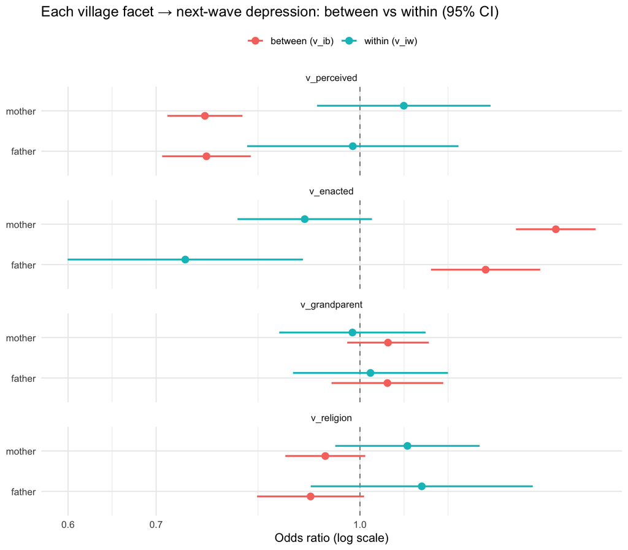

```r
  fp <- bind_rows(
    W |> transmute(facet, parent, term = "between (v_ib)", OR = between_OR, lo = between_lo, hi = between_hi),
    W |> transmute(facet, parent, term = "within (v_iw)",  OR = within_GEE_OR, lo = within_lo, hi = within_hi)) |>
    mutate(facet = factor(facet, levels = c("v_perceived","v_enacted","v_grandparent","v_religion")))
  ggplot(fp, aes(OR, parent, color = term)) +
    geom_vline(xintercept = 1, linetype = 2, color = "grey50") +
    geom_pointrange(aes(xmin = lo, xmax = hi), position = position_dodge(0.5), linewidth = 0.8) +
    facet_wrap(~ facet, ncol = 1) +
    scale_x_log10() +
    labs(title = "Each village facet → next-wave depression: between vs within (95% CI)",
         x = "Odds ratio (log scale)", y = NULL, color = NULL) +
    theme_minimal() + theme(legend.position = "top")
```

# 9 Rung 2 — Sensitivity to unmeasured confounding (E-value)

```r
# How strong an unmeasured confounder would need to be to explain away the between-person
# effect — E-value for the point estimate AND the CI limit nearest the null (VanderWeele & Ding 2017).
base_p0 <- tapply(panel$dep_t, panel$parent, function(v) mean(v, na.rm = TRUE))  # baseline outcome prevalence by parent
W |>
  filter(facet == "v_perceived") |>             # E-value interpretable for the headline protective effect
  transmute(parent, between_OR, between_hi,
            p0       = base_p0[parent],          # named lookup → robust to row order & multi-facet
            RR_point = or2rr(between_OR, p0),  E_point = evalue(RR_point),
            RR_CI    = or2rr(between_hi, p0),  E_CI    = evalue(RR_CI)) |>
  knitr::kable(digits = 3,
    caption = "E-value for the between-person PERCEIVED-support effect (point estimate and CI limit nearest the null)")
```

E-value for the between-person PERCEIVED-support effect (point estimate and CI limit nearest the null)

| parent | between_OR | between_hi | p0 | RR_point | E_point | RR_CI | E_CI |
| --- | --- | --- | --- | --- | --- | --- | --- |
| mother | 0.762 | 0.814 | 0.1841276 | 0.7972346 | 1.819157 | 0.8429471 | 1.656449 |
| father | 0.764 | 0.826 | 0.1309569 | 0.7887595 | 1.850512 | 0.8453249 | 1.648227 |

An unmeasured confounder associated with both perceived support and depression by a risk ratio of only ~1.8 (point estimate; ~1.6 at the CI limit nearest the null) would fully explain the between-person association — and stable negative affectivity clears that easily.

# 10 Rung 3 — Cross-lagged reverse test (rules out reverse causation)

> **Rung 3 of 4 · the direction check.** *Removes:* the possibility the arrow runs backward — depression eroding *future* support rather than support protecting against depression. A within-person reverse-null, paired with the forward-null, is the fingerprint of a stable common cause (confounding), not causation in either direction.

Does depression at *t* predict **lower support at t+1** (controlling support at *t*)? If the within-person reverse effect is also null, the relationship is purely a stable between-person bundle.

```r
sup_wave <- base |> select(idnum, parent, wave, support = v_instrumental, dep = md_case_lib,
                           fh, poverty_cat, par_edu)
rev_pairs <- do.call(rbind, lapply(list(c(2,3), c(3,4), c(4,5)), function(pr){
  a <- sup_wave |> filter(wave == pr[1]); b <- sup_wave |> filter(wave == pr[2])
  b |> select(idnum, parent, support_t1 = support) |>
    inner_join(a |> select(idnum, parent, dep_t0 = dep, support_t0 = support, fh, poverty_cat, par_edu),
               by = c("idnum","parent"))
}))
rev_tab <- bind_rows(lapply(c("mother","father"), function(p){
  d <- rev_pairs |> filter(parent == p) |> na.omit() |> arrange(idnum)
  d <- d |> group_by(idnum) |> mutate(dep_btw = mean(dep_t0), dep_wth = dep_t0 - dep_btw) |> ungroup()
  m <- geeglm(support_t1 ~ dep_btw + dep_wth + support_t0 + fh + poverty_cat + par_edu,
              id = idnum, data = d, family = gaussian, corstr = "exchangeable")
  cf <- summary(m)$coefficients
  # FE cross-check: an INDEPENDENT within-OLS (person-demeaned) estimate of the reverse effect,
  # mirroring the forward test's dual-estimator design. It is not numerically identical to the
  # GEE within term (GEE uses an exchangeable working correlation, OLS does not), but both should
  # land near zero. Also report how many parents have discordant prior depression.
  dw <- d |> group_by(idnum) |>
    mutate(dplyr::across(c(support_t1, dep_t0, support_t0), ~ .x - mean(.x))) |> ungroup()
  fe <- lm(support_t1 ~ dep_t0 + support_t0 + 0, data = dw)
  n_disc <- d |> group_by(idnum) |> summarise(v = (max(dep_t0) - min(dep_t0)) > 0, .groups = "drop")
  data.frame(parent = p, n_dep_discordant = sum(n_disc$v),
             between_dep_effect = cf["dep_btw","Estimate"], between_p = cf["dep_btw","Pr(>|W|)"],
             within_dep_effect  = cf["dep_wth","Estimate"], within_p  = cf["dep_wth","Pr(>|W|)"],
             within_FE_lm       = unname(coef(fe)["dep_t0"]))
}))
knitr::kable(rev_tab, digits = 4, row.names = FALSE,
             caption = "Reverse lag: depression -> change in next-wave support")
```

Reverse lag: depression -> change in next-wave support

| parent | n_dep_discordant | between_dep_effect | between_p | within_dep_effect | within_p | within_FE_lm |
| --- | --- | --- | --- | --- | --- | --- |
| mother | 906 | -0.0507 | 0 | 0.0106 | 0.3440 | -0.0138 |
| father | 441 | -0.0463 | 0 | 0.0146 | 0.3482 | -0.0029 |

The reverse arrow is also **between-person only** (chronically-depressed people report declining support) and **null within-person**. Combined with the forward null, **neither arrow operates within individuals** — the signature of a stable common cause, not causation in either direction.

# 11 Rung 4 — Terminal test: the original thesis, cleanest slice

> **Rung 4 of 4 · the decisive case.** *Tests:* among low-vulnerability (`fh = 0`), previously-well parents — the slice where “a Village mends them” is *most* likely to hold — does support prevent **new-onset** depression within persons? If it fails even here, it fails everywhere.

“Parenting broke them, did a Village mend them?” Among **low-vulnerability (`fh=0`), previously-well** parents — the cleanest pro-thesis slice — does support prevent **new-onset** depression?

```r
sub_tab <- bind_rows(lapply(c("mother","father"), function(p){
  d <- panel |> filter(parent == p, fh == 0, dep_prev == 0) |>
    select(idnum, dep_t, wave_out, v_instrumental, poverty_cat, par_edu) |> na.omit()
  d$v_instrumental <- z(d$v_instrumental); d$poverty_cat <- z(d$poverty_cat); d$par_edu <- z(d$par_edu)
  d <- d |> group_by(idnum) |> mutate(v_ib = mean(v_instrumental), v_iw = v_instrumental - v_ib) |>
    ungroup() |> arrange(idnum)
  mA <- geeglm(dep_t ~ v_instrumental + poverty_cat + par_edu + factor(wave_out),
               id = idnum, data = d, family = binomial, corstr = "exchangeable")
  mB <- geeglm(dep_t ~ v_ib + v_iw + poverty_cat + par_edu + factor(wave_out),
               id = idnum, data = d, family = binomial, corstr = "exchangeable")
  ca <- summary(mA)$coefficients; cb <- summary(mB)$coefficients
  data.frame(parent = p, new_onset_events = sum(d$dep_t),
             naive_OR = exp(ca["v_instrumental","Estimate"]),
             between_OR = exp(cb["v_ib","Estimate"]),
             within_OR = exp(cb["v_iw","Estimate"]), within_p = cb["v_iw","Pr(>|W|)"])
}))
knitr::kable(sub_tab, digits = 3, row.names = FALSE,
             caption = "Low-fh new-onset subgroup: support -> new-onset depression")
```

Low-fh new-onset subgroup: support -> new-onset depression

| parent | new_onset_events | naive_OR | between_OR | within_OR | within_p |
| --- | --- | --- | --- | --- | --- |
| mother | 534 | 0.823 | 0.767 | 1.024 | 0.767 |
| father | 313 | 0.825 | 0.774 | 0.988 | 0.895 |

Same pattern even here: the naive/between association looks protective, the **within-person effect is null**. The Village did not mend them — supported fresh parents fare better only because they are different *people*.

# 12 Synthesis — the vulnerability triad

> *Ladder complete — Rungs 1–4 converge on a within-person null. This section steps off the ladder to integrate the **descriptive** layer (Stage-1 clustering) with the **causal** layer (the ladder): the answer to the title’s “cause or signature?” question.*

Do the trajectory classes carry the support and family-history signatures?

```r
syn <- bind_rows(lapply(c("mother","father"), function(p){
  pm <- support_long |> filter(parent == p) |> group_by(idnum) |>
    summarise(support_mean = mean(v_instrumental, na.rm = TRUE), .groups = "drop")
  G[[p]]$units |> left_join(pm, by = "idnum") |>
    left_join(vuln |> select(idnum, fh = !!paste0("fh_", p)), by = "idnum") |>
    group_by(class) |>
    summarise(n = n(), support_mean = mean(support_mean, na.rm = TRUE),
              fh_prev = mean(fh, na.rm = TRUE), .groups = "drop") |> mutate(parent = p)
}))
knitr::kable(syn, digits = 3, caption = "Support and family-history by trajectory class")
```

Support and family-history by trajectory class

| class | n | support_mean | fh_prev | parent |
| --- | --- | --- | --- | --- |
| persistent | 488 | 0.60 | 0.620 | mother |
| rarely | 2340 | 0.75 | 0.283 | mother |
| persistent | 318 | 0.67 | 0.594 | father |
| rarely | 2127 | 0.79 | 0.266 | father |

The **persistent** class reports markedly lower support **and** carries roughly double the family-history prevalence. The “vulnerable” trajectory is best read as a single stable disposition expressed as a *triad* — persistent depression, low perceived support, elevated family history — none of which causally moves the others within a person. Support and `fh` are **signatures** of membership, not separate causal levers.

# 13 Anxiety (GAD) — secondary outcome

The CIDI also yields **generalized-anxiety caseness**, but it was fielded **only at Years 1 & 3**. Two waves means **no trajectory clustering and no within-person identification** (a single Y1→Y3 transition cannot separate within- from between-person variation). Anxiety therefore enters as a *secondary, between-person* check: prevalence, comorbidity with depression, and a single prospective Y1→Y3 association.

```r
anx <- long |> filter(wave %in% GAD_WAVES, !is.na(gad_case))
anx |> group_by(parent, wave) |>
  summarise(n = n(), gad_prev = mean(gad_case),
            phi_with_depression = cor(gad_case, md_case_lib, use = "complete.obs"), .groups = "drop") |>
  mutate(child_age = WAVE_LABEL[as.character(wave)]) |>
  knitr::kable(digits = 3, caption = "GAD caseness prevalence and comorbidity with depression (same wave)")
```

GAD caseness prevalence and comorbidity with depression (same wave)

| parent | wave | n | gad_prev | phi_with_depression | child_age |
| --- | --- | --- | --- | --- | --- |
| father | 2 | 3373 | 0.025 | 0.323 | Year 1 |
| father | 3 | 3285 | 0.033 | 0.308 | Year 3 |
| mother | 2 | 4357 | 0.031 | 0.297 | Year 1 |
| mother | 3 | 4221 | 0.045 | 0.325 | Year 3 |

GAD is much rarer than depression (~2.5–5%) and **heavily comorbid** — most anxiety cases are also depression cases (φ ≈ 0.3), so anxiety is largely a severity marker within the same distress dimension, not an independent outcome.

```r
gad_w <- long |> filter(wave %in% GAD_WAVES) |> select(idnum, parent, wave, gad_case) |>
  tidyr::pivot_wider(names_from = wave, values_from = gad_case, names_prefix = "gad_w")
sup1 <- support_long |> filter(wave == 2) |> select(idnum, parent, support_y1 = v_instrumental)
cov1 <- long |> filter(wave == 2) |> select(idnum, parent, poverty_cat, par_edu) |> distinct()
anx_tab <- bind_rows(lapply(c("mother","father"), function(p){
  d <- gad_w |> left_join(sup1, by = c("idnum","parent")) |>
    left_join(fh_long, by = c("idnum","parent")) |> left_join(cov1, by = c("idnum","parent")) |>
    filter(parent == p) |>
    select(gad_w3, support_y1, gad_w2, fh, poverty_cat, par_edu) |> na.omit()
  d$support_y1 <- z(d$support_y1); d$poverty_cat <- z(d$poverty_cat); d$par_edu <- z(d$par_edu)
  m <- glm(gad_w3 ~ support_y1 + gad_w2 + fh + poverty_cat + par_edu, data = d, family = binomial)
  s <- summary(m)$coefficients
  data.frame(parent = p, n = nrow(d), gad_y3_events = sum(d$gad_w3),
             support_OR = exp(s["support_y1","Estimate"]), support_p = s["support_y1","Pr(>|z|)"],
             fh_OR = exp(s["fh","Estimate"]), fh_p = s["fh","Pr(>|z|)"])
}))
knitr::kable(anx_tab, digits = 3, row.names = FALSE,
             caption = "Y1 support -> Y3 anxiety (between-person; controlling Y1 anxiety, fh, SES)")
```

Y1 support -> Y3 anxiety (between-person; controlling Y1 anxiety, fh, SES)

| parent | n | gad_y3_events | support_OR | support_p | fh_OR | fh_p |
| --- | --- | --- | --- | --- | --- | --- |
| mother | 3669 | 162 | 0.807 | 0.007 | 3.975 | 0 |
| father | 2626 | 73 | 0.688 | 0.000 | 4.264 | 0 |

This is a **between-person** prospective association only (the within-person test is not identifiable with two waves) and is **low-powered** (few GAD events). Read it as a directional check on whether the depression pattern extends to anxiety — not as a co-equal result.

# 14 Conclusions & limitations

**Findings.**

1. Parental depression is **trait-like / vulnerability-driven**, not an infant-period spike; clean 2-class structure for both parents.
2. **Family-history vulnerability dominates SES** in predicting the persistent class; SES is largely confounded by vulnerability.
3. Social support (“the Village”) is **protective between persons but null within persons** (both estimators, both parents), with a null buffering interaction. This holds across a **four-facet ablation**: perceived support (protective-between/null-within), enacted support (mobilization, reverse-signed between; a non-robust father within-effect), grandparent co-residence (null throughout), and **religious participation** (a weak, non-significant between-person correlate with no within-person effect and no added predictive signal).
4. The **cross-lagged** test is symmetric: no within-person dynamics in either direction → a stable between-person bundle (confounding), not causation.
5. The **low-vulnerability new-onset** terminal test confirms it: the Village did not prevent onset within individuals.
6. **Synthesis:** the vulnerable trajectory class is one disposition surfacing as a triad (persistent depression + low support + family history).

**Limitations.**